# Piney Point trends synthesis

MW Beck

20 September, 2022

## Region delineation

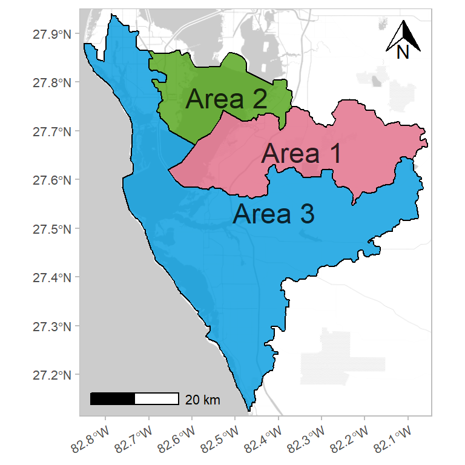

## Sampling maps

download

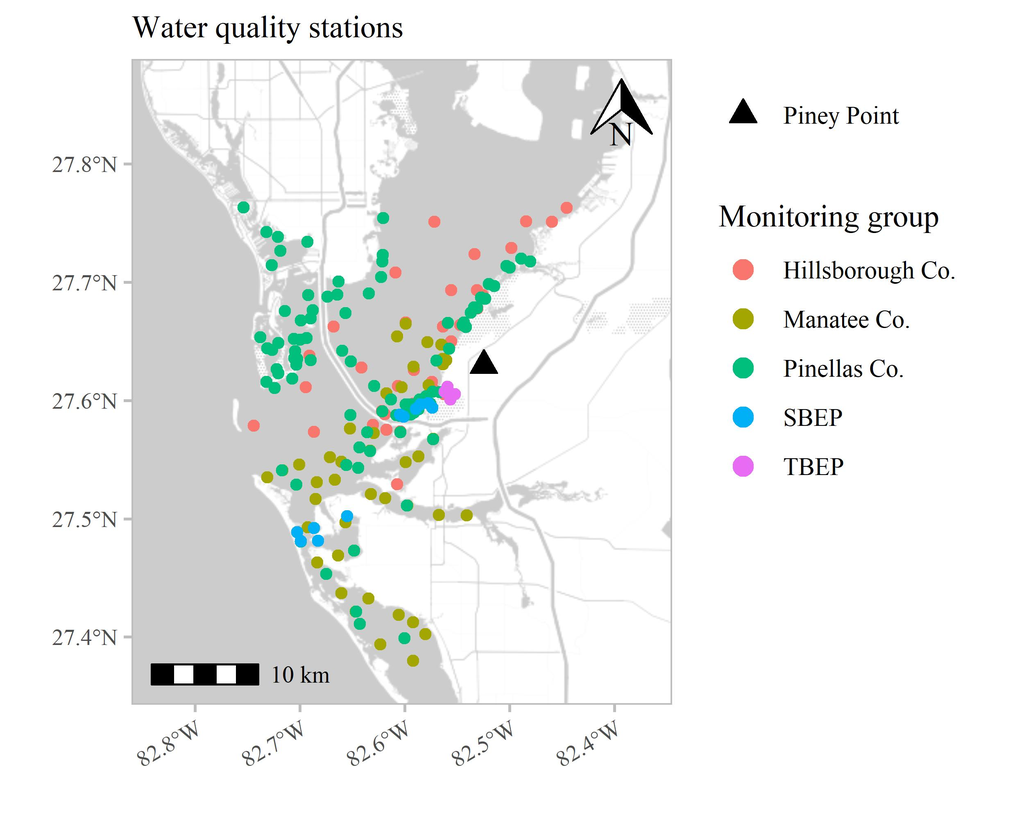

download

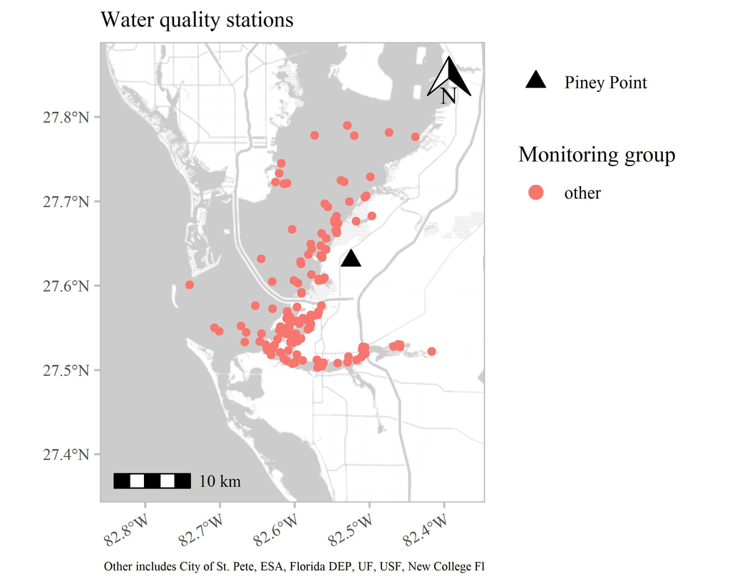

download

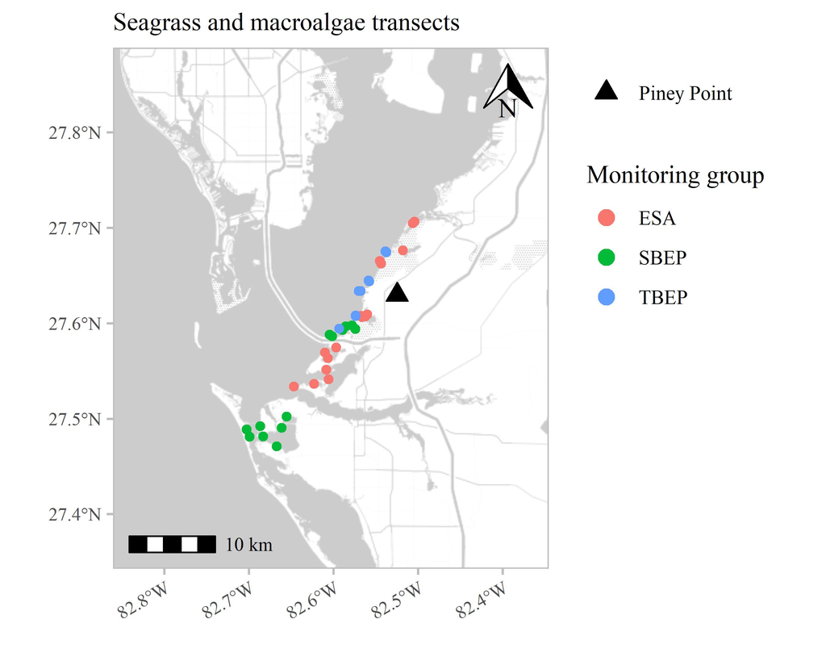

download

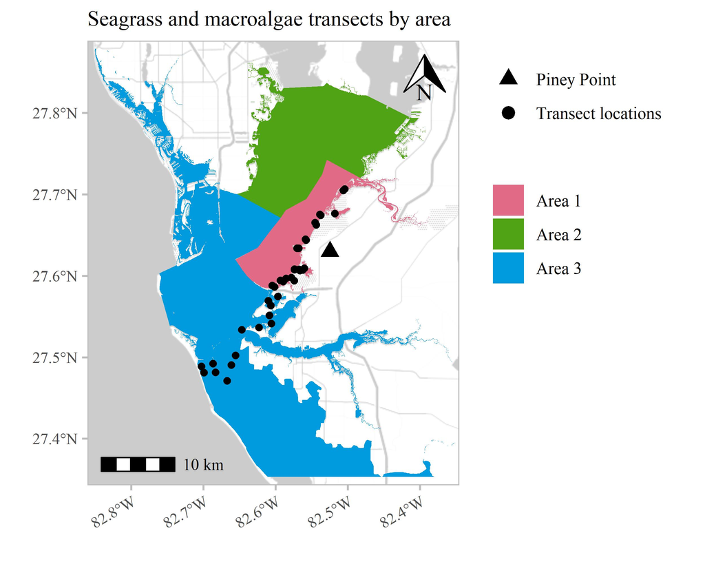

## Water Quality

### TN

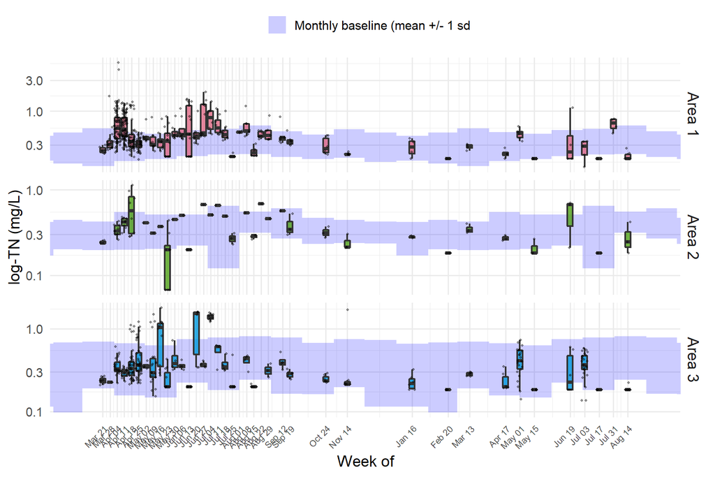

### NH3

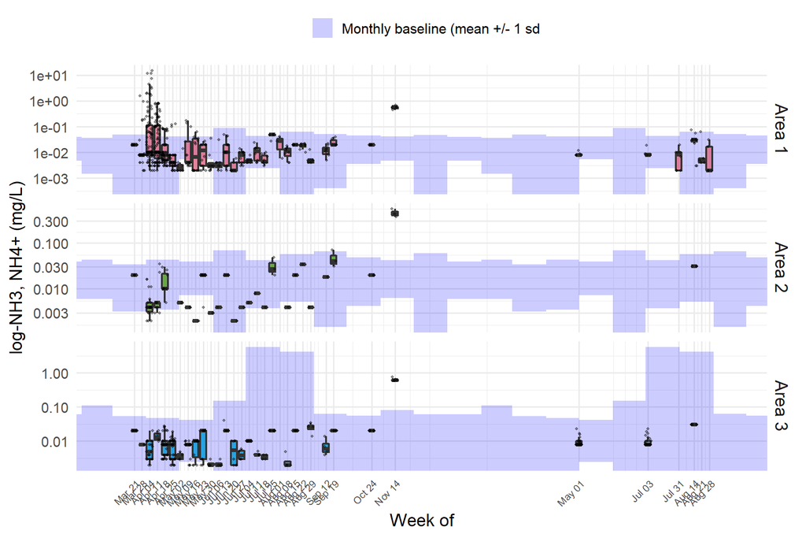

### TP

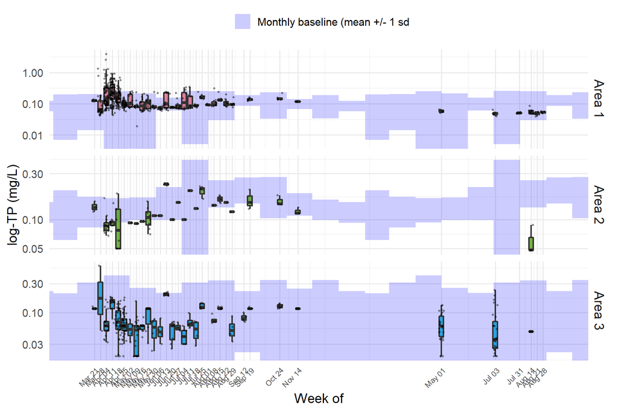

### Chl

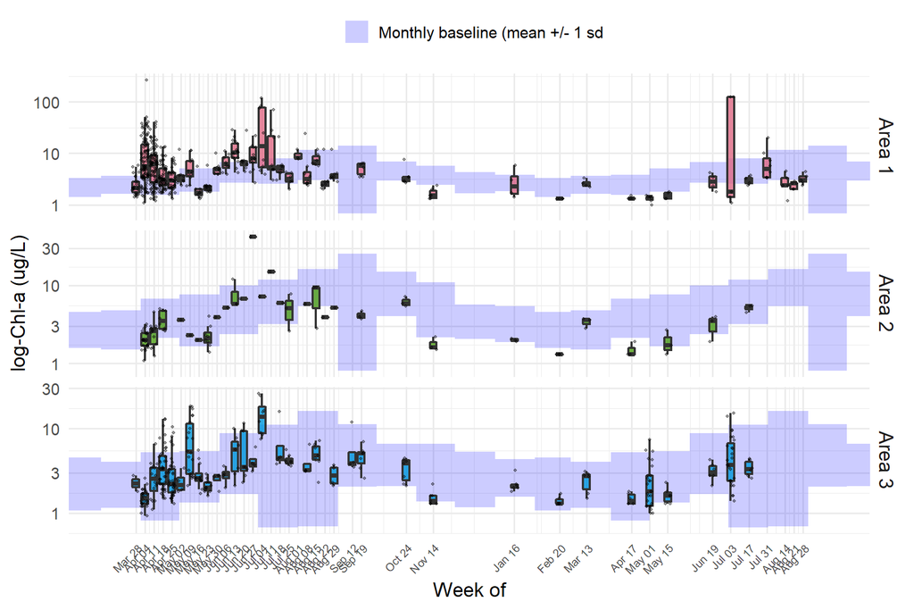

### DO Sat.

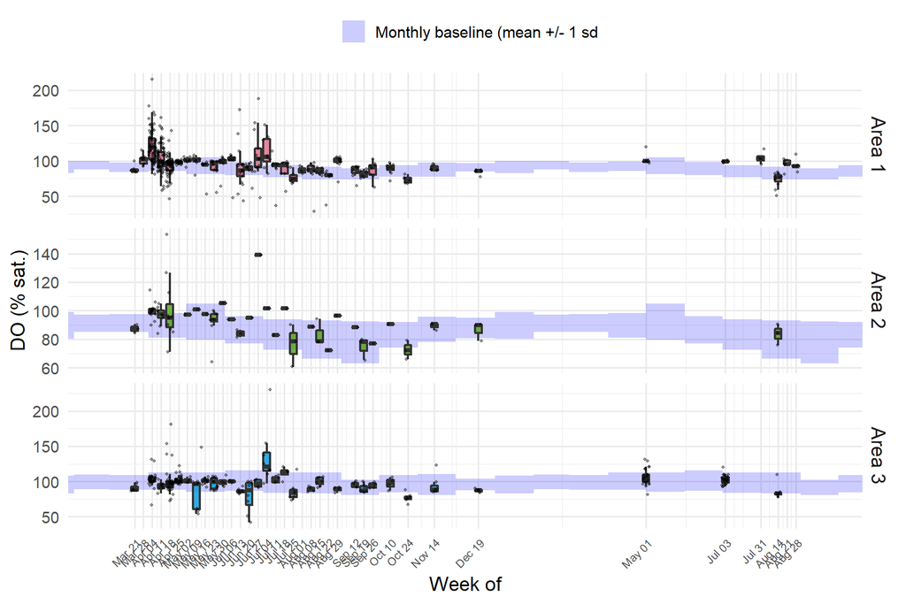

### Aug/Sep 2021 v 2022

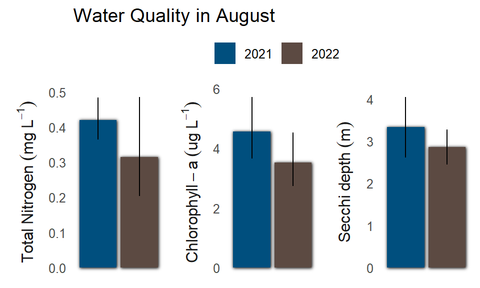

## Phytoplankton

### Mixed algae

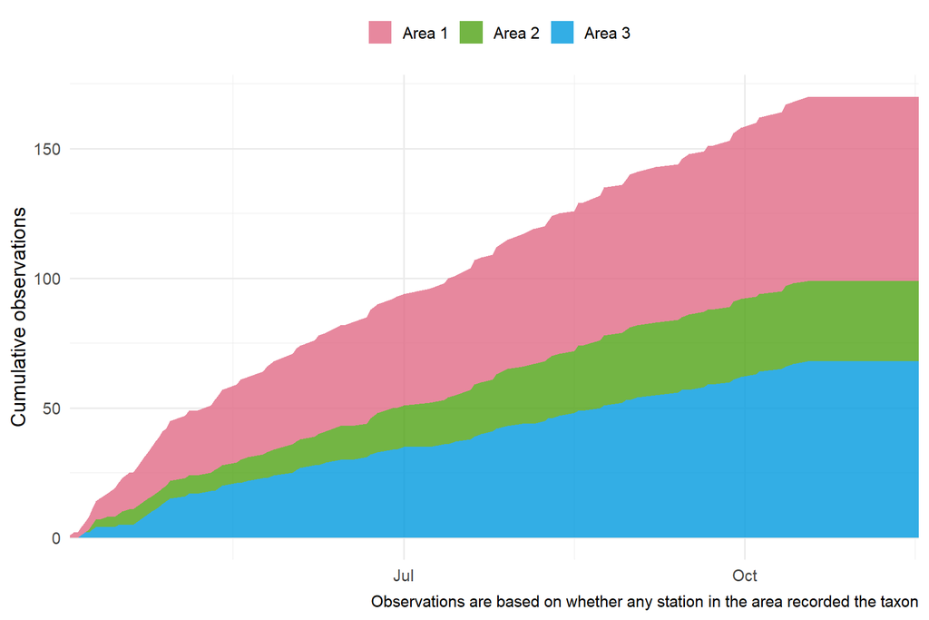

### Centric diatoms

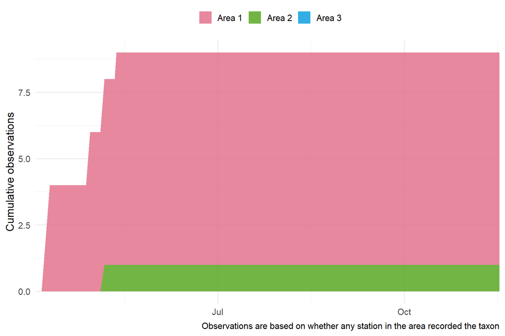

### Bacillariophyta

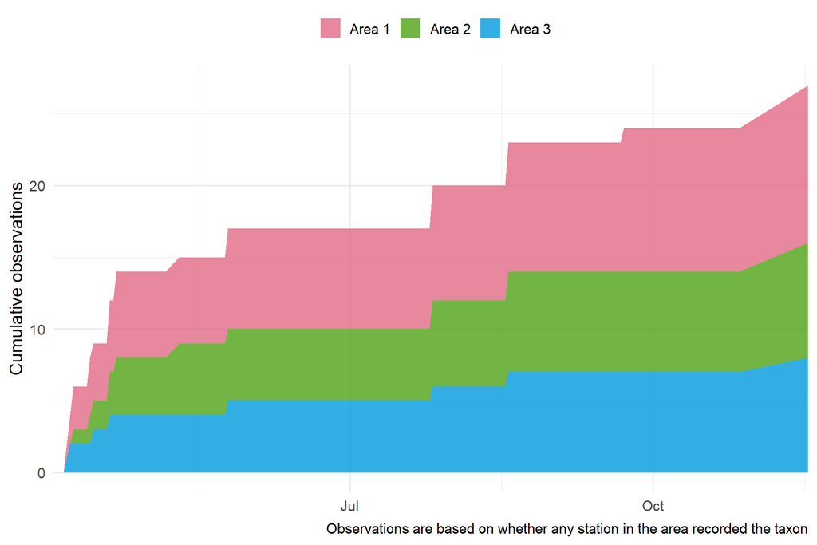

### Karenia brevis

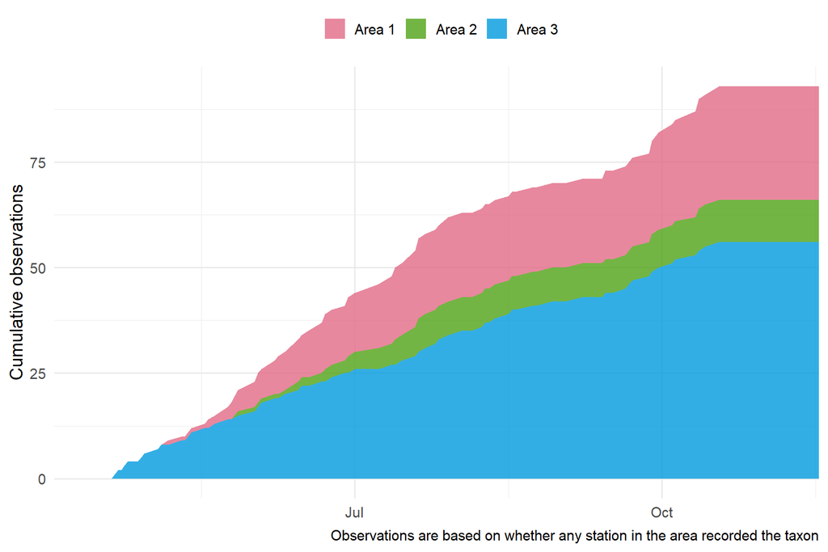

### Pseudo-nitzschia sp.

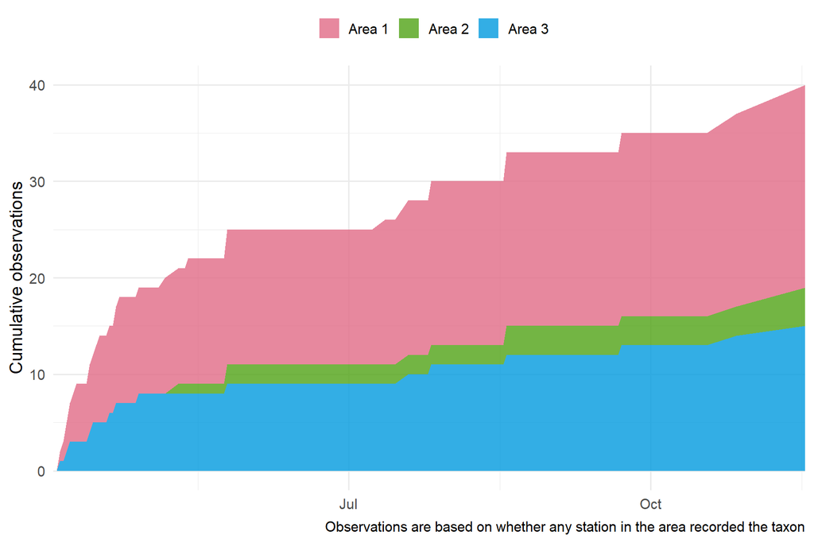

### Rhizosolenia setigera

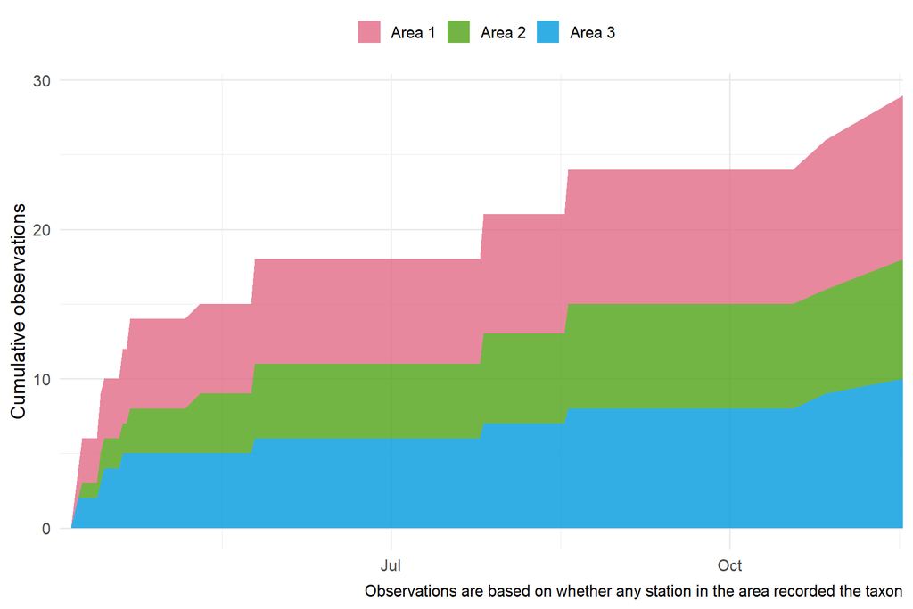

## Seagrass

### Overall

Note that the “total” category applies if any seagrass or macroalgae were present along a transect and is not the sum of the individual frequency occurrences.

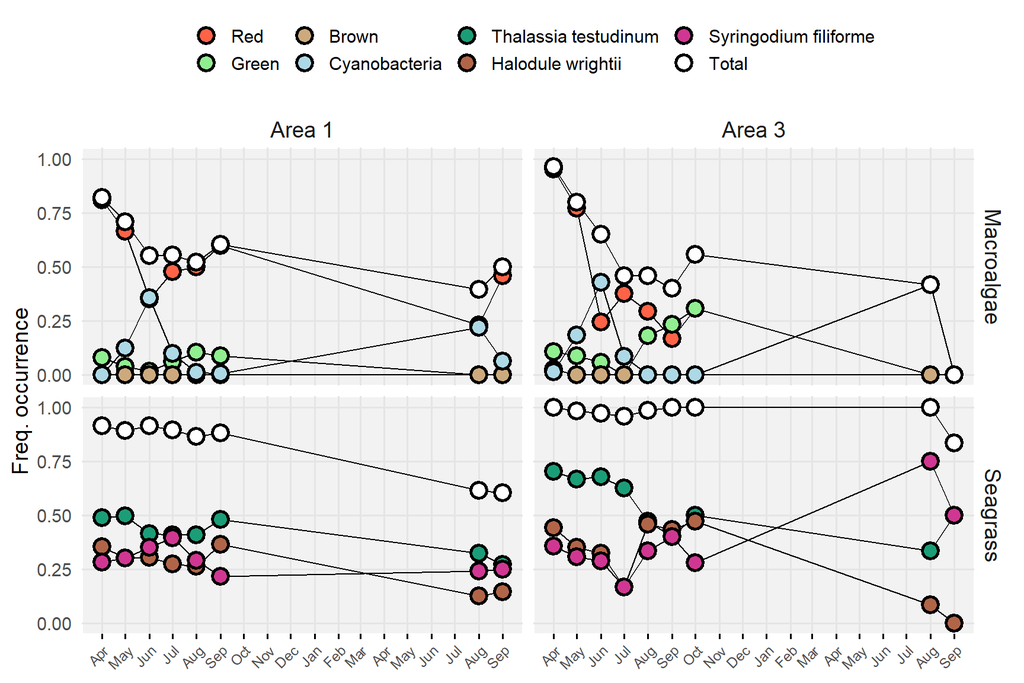

The same plot as above but aggregated across all transects.

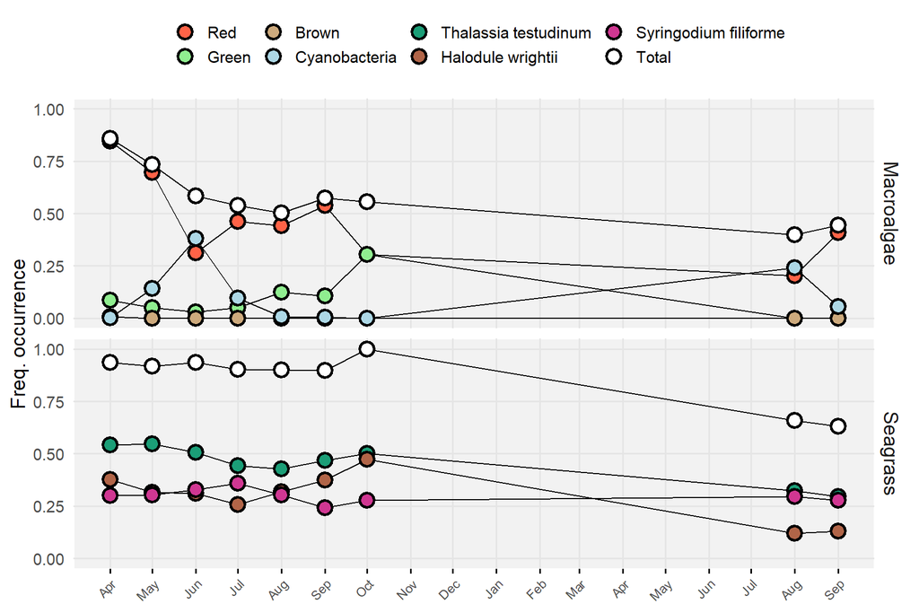

Macroalgae only.

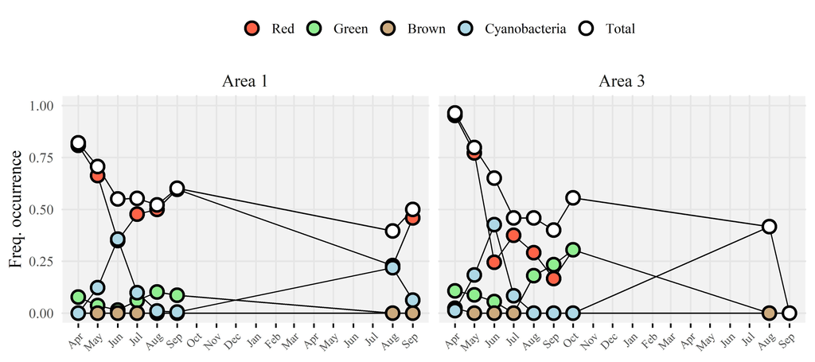

### SAV vs macroalgae, by station

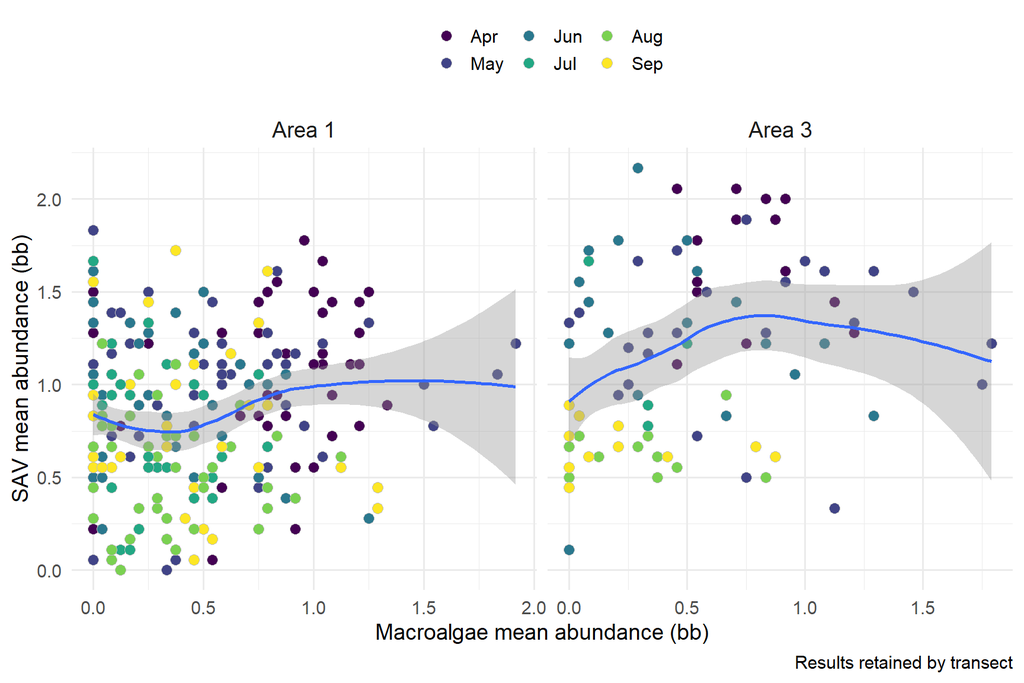

### Water quality vs macroalgae vs SAV

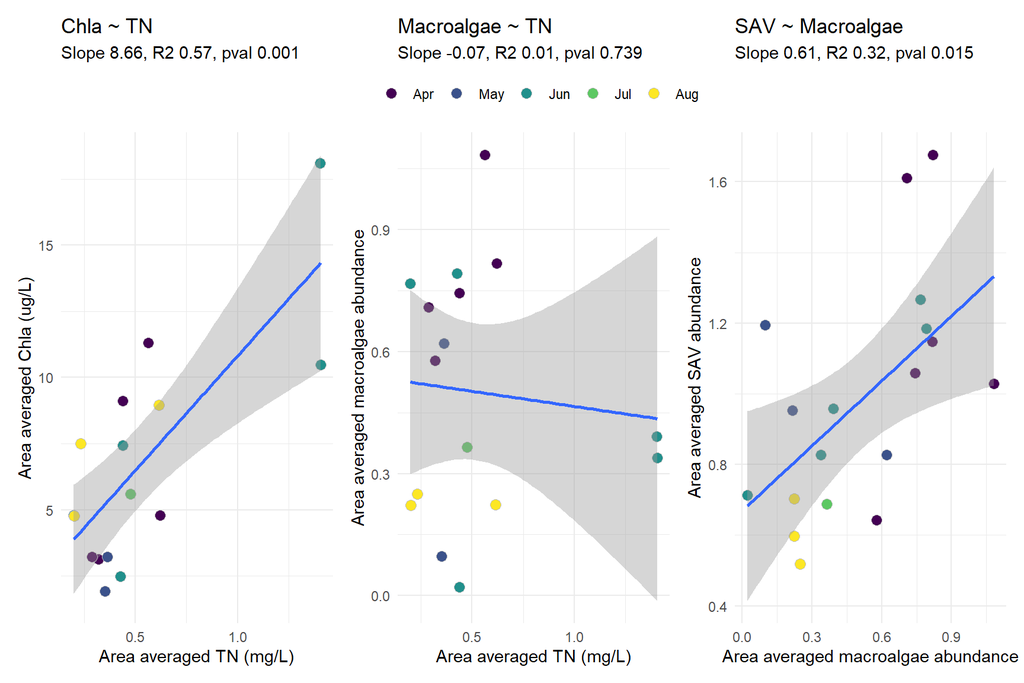

### Water quality vs macroalge vs SAV, correlations

This correlation matrix shows correlations between seagrasses, macroalgae, and water quality. Seagrass and macroalgae are correlated at the transect scale, i.e., observations are compared at the same location over time. The water quality comparisons to the other variables are at an aggregated spatial scale because of different sample locations for the transects and water quality.

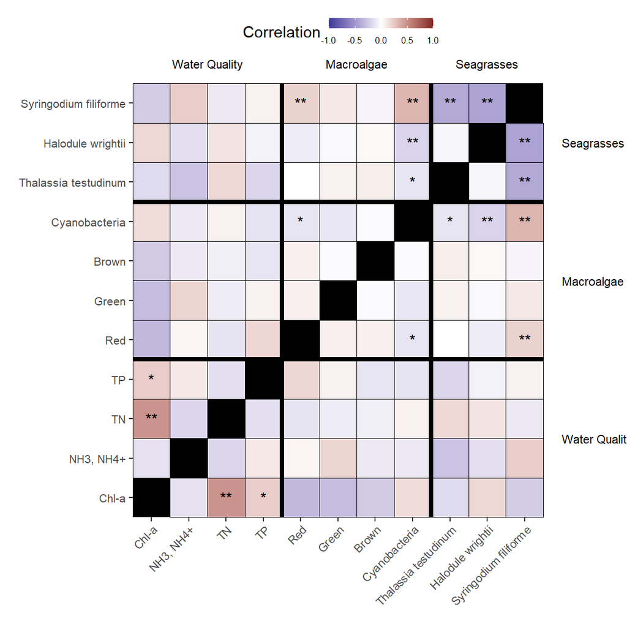

### Biomass estimates

Simple regressions of weight vs abundance by major macroalgae group. Regressions are fit through the origin so that zero weight is fixed at zero mass.

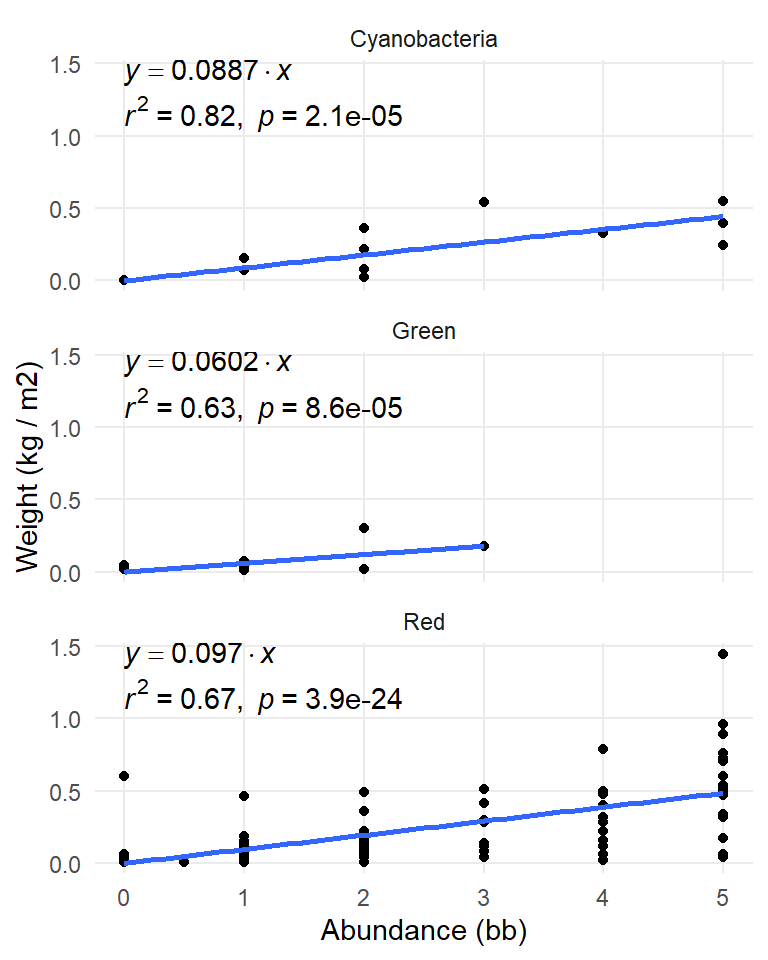

Using the regression, a weight was assigned to all macroalgae samples where abundance (bb) was recorded. The weights were then summed across all quadrats by transect, macroalgae group, month, and region ([here](https://tbep-tech.github.io/piney-point-analysis/trends#region-delineation)) to represent total sampled biomass. However, this is biased by relative sample effort (Area 1 has been sampled ~3x more than Area 3). Below, the weights are standardized to unit effort.

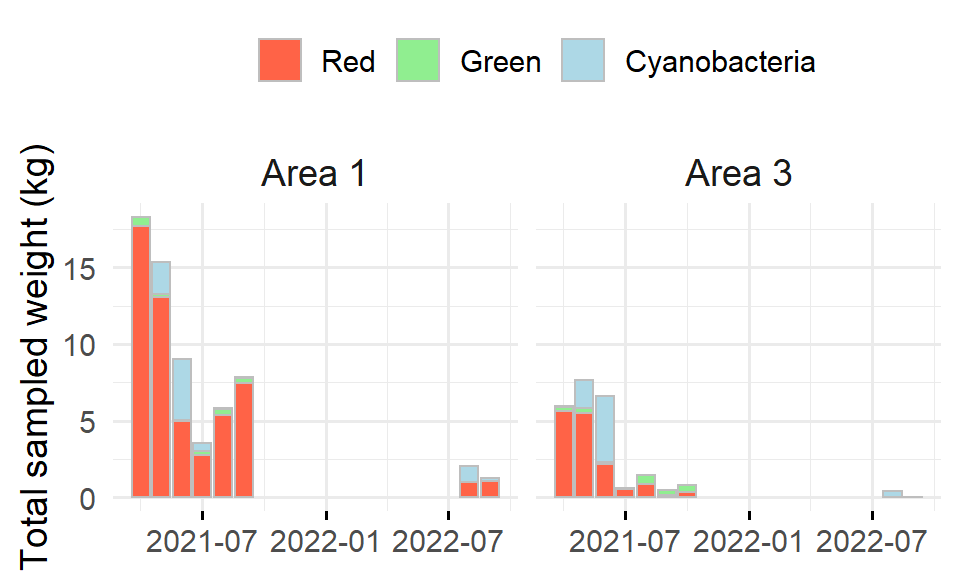

Because of different sampling effort by month and location, weights were standardized by dividing by sample effort (number of unique transect visits in a month). This can also be considered as kg / 1.25 m2 because five quadrats of 0.25 m2 are surveyed each transect. So converting this to kg / m2, the weights are multiplied by 0.8 (1 / 1.25).

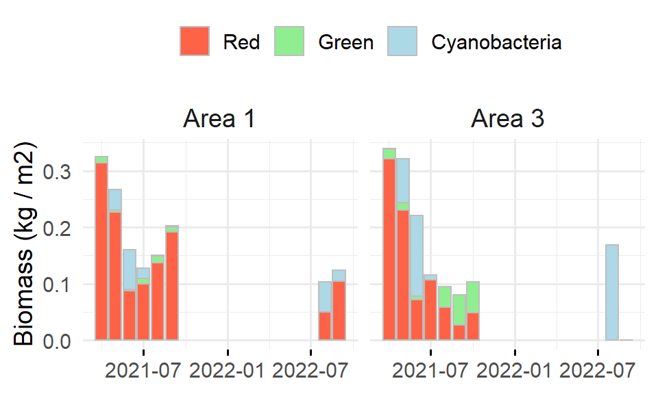

### August 2021 v 2022

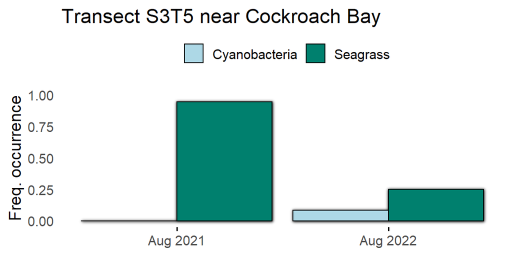